# Analysis of Injury Risk for NFL Players

Weijia Bao, Jiyuan Liu, Yakun Wang, Marshall Zhao

12/5/2019

```r
packages.used=c("tidyverse", "ggplot2","vcd","ggmosaic","GGally","lubridate","scales","DMwR","gridExtra")
# check packages that need to be installed.
packages.needed=setdiff(packages.used,
                        intersect(installed.packages()[,1],
                                  packages.used))
# install additional packages
if(length(packages.needed)>0){
  install.packages(packages.needed, dependencies = TRUE)
}
```

```r
# load packages
library(tidyverse)
library(ggplot2)
library(vcd)
library(ggmosaic)
library(GGally)
library(lubridate)
library(scales)
library(DMwR)
library(gridExtra)
```

## Data Introduction

Injury Record: The injury record file contains information on 105 lower-limb injuries that occurred during regular season games over the two seasons.

Play list: The playlist file contains the details for the over 260 thousand player-plays that makeup the dataset. Details about the game and play include the player’s assigned roster position, stadium type, field type, weather, play type and so on.

Player Track Data has player level data that describes the location, orientation, speed and direction of each player during a play recorded at 10 Hz( i.e 10 observations recorded per second.)

[figure not shown]

We are trying to analyze (National Football League)NFL non-contact lower-limb injury data over 2 regular seasons, and to identify different player movements on different field surfaces, weather, positions and etc that may influence the risk of injury.

## Data Processing

```r
## Pre-processing the dataset
NFL_data_new$indicator <- as.factor(NFL_data_new$indicator)
##Using SMOTE method to generate minority dataset and sample from majority
## in respond to proportion of injured player percentage
NFL_data_resample <- SMOTE(indicator ~ ., NFL_data_new, perc.over = 4900, k=5, perc.under=300)

print(table(NFL_data_resample$indicator))
print(prop.table(table(NFL_data$indicator)))

NFL_data_resample$indicator <- ifelse(NFL_data_resample$indicator==0,"non-injured","injured")
print(table(NFL_data_resample$indicator))
save(NFL_data_resample, file="../output/NFL_data_resample.RData")
```

```r
load('../output/NFL_data_resample.RData')
InjuryRecord <- read.csv("../data/InjuryRecord.csv")
PlayList <- read.csv("../data/PlayList.csv")
# PlayerTrackData <- read.csv("../data/PlayerTrackData.csv")
```

## Logic Tree

We do analysis base on the following logic.

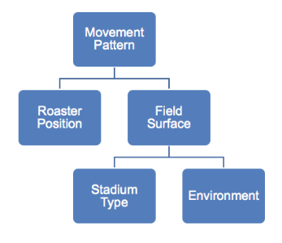

## One Track Animation (Injured)

Instead of one single player, we take one single track of player movements as the basic unit. Because environment changes and the players change their movement patterns in each game.

Here, we display an example of an injured player’s track. We locate the instant location (change by 10hz) of this player on the left-hand side, while on the right-hand-side, we have direction, acceleration, speed for each time break.

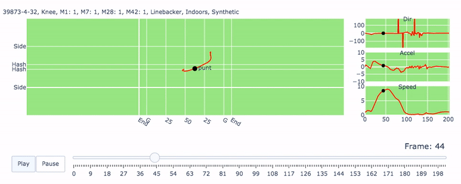

## Roaster Position

```r
unique.player<-duplicated(PlayList$PlayerKey)
dat_palyer <- PlayList[!unique.player,]
dat_palyer$indicator <- ifelse(dat_palyer$PlayerKey %in% InjuryRecord$PlayerKey, "Injured", "Non-Injured")
```

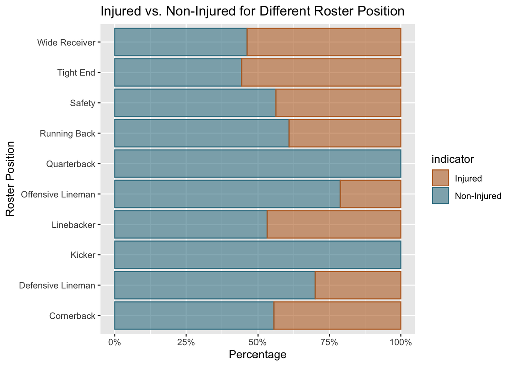

```r
plot_cols <- c("#498972", "#3E8193", "#BC6E2E", "#A09D3C", "#E06E77", "#7589BC", "#A57BAF", "#4D4D4D")
dat_palyer %>%
  ggplot(aes(x=RosterPosition, fill = indicator, colour = indicator)) +
  geom_bar(stat = "count", position = "fill", alpha = 0.6) +
  scale_fill_manual(values = plot_cols[c(3,2)]) +
  scale_colour_manual(values = plot_cols[c(3,2)]) +
  scale_y_continuous(labels = percent) + labs(x = "Roster Position", y="Percentage")+
  ggtitle("Injured vs. Non-Injured for Different Roster Position") + coord_flip()
```

```r
table(dat_palyer$RosterPosition,dat_palyer$indicator)
```

```
##
##                     Injured Non-Injured
##   Cornerback             12          15
##   Defensive Lineman       9          21
##   Kicker                  0           3
##   Linebacker             22          25
##   Offensive Lineman       7          26
##   Quarterback             0           5
##   Running Back            9          14
##   Safety                 14          18
##   Tight End               5           4
##   Wide Receiver          22          19
```

```r
fisher.test(table(dat_palyer$RosterPosition, dat_palyer$indicator),workspace = 2e8)
```

```
##
##  Fisher's Exact Test for Count Data
##
## data:  table(dat_palyer$RosterPosition, dat_palyer$indicator)
## p-value = 0.04918
## alternative hypothesis: two.sided
```

From the stacked bar plot, we propose that there is an association between injured cases and with different Roster Positions. the later fisher’s exact test proves our hypothesis.

### a. Roaster Position + Speed mean and variance

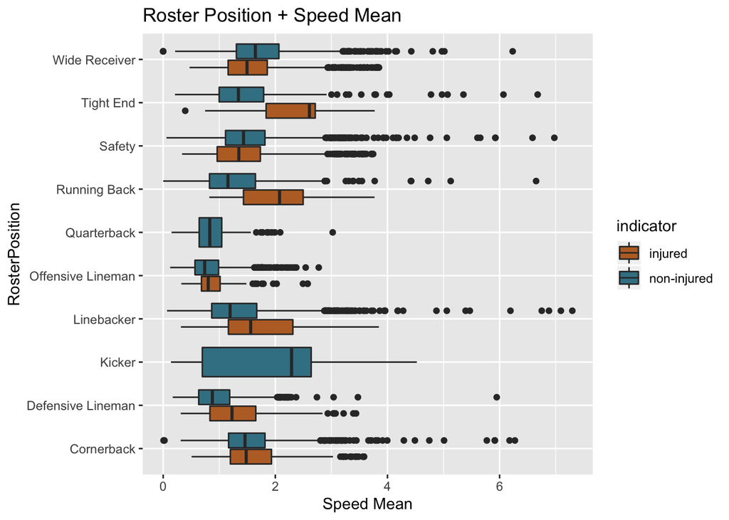

```r
ggplot(NFL_data_resample,aes(x=RosterPosition,y=mean_speed,fill=indicator)) +
  geom_boxplot() +
  scale_fill_manual(values = plot_cols[c(3,2)]) +
  scale_colour_manual(values = plot_cols[c(3,2)]) +
  labs(x="RosterPosition",y="Speed Mean")+
  ggtitle("Roster Position + Speed Mean") +
  coord_flip()
```

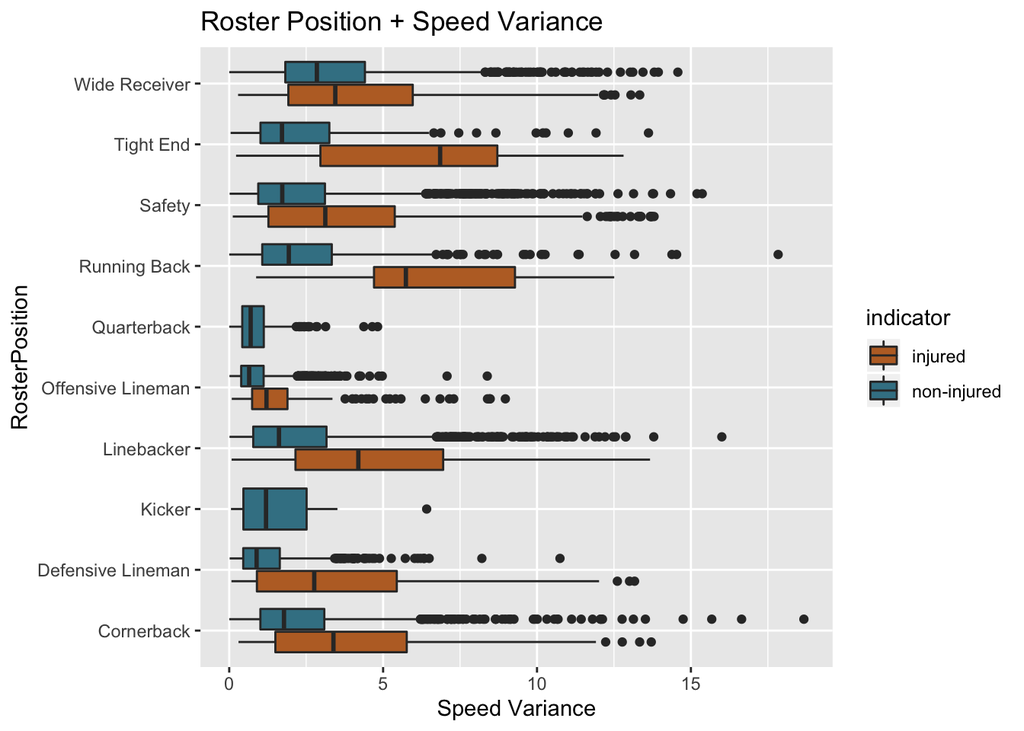

```r
ggplot(NFL_data_resample,aes(x=RosterPosition,y=var_speed,fill=indicator)) +
  geom_boxplot() +
  scale_fill_manual(values = plot_cols[c(3,2)]) +
  scale_colour_manual(values = plot_cols[c(3,2)]) +
  labs(x="RosterPosition",y="Speed Variance")+
  ggtitle("Roster Position + Speed Variance") +
  coord_flip()
```

We studied movement patterns of injury/noninjury tracks for each roster position. You can see from these plots, tight ends, running backs and linebackers tend to have larger average speed and greater deviance during their injured tracks than non-injured tracks.

### b. Roaster Position + |ΔDirection| mean, variance

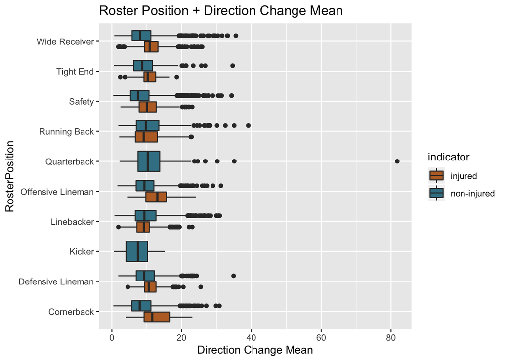

```r
ggplot(NFL_data_resample,aes(x=RosterPosition,y=mean_dir,fill=indicator)) +
  geom_boxplot() +
  scale_fill_manual(values = plot_cols[c(3,2)]) +
  scale_colour_manual(values = plot_cols[c(3,2)]) +
  labs(x="RosterPosition",y="Direction Change Mean")+
  ggtitle("Roster Position + Direction Change Mean") +
  coord_flip()
```

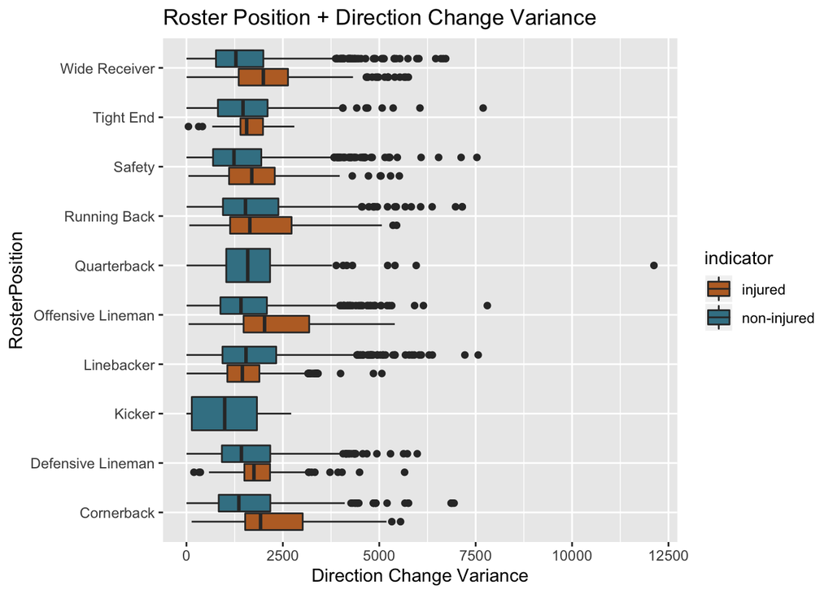

```r
ggplot(NFL_data_resample,aes(x=RosterPosition,y=var_dir,fill=indicator)) +
  geom_boxplot() +
  scale_fill_manual(values = plot_cols[c(3,2)]) +
  scale_colour_manual(values = plot_cols[c(3,2)]) +
  labs(x="RosterPosition",y="Direction Change Variance")+
  ggtitle("Roster Position + Direction Change Variance") +
  coord_flip()
```

Similar patterns were shown for absolute angle changes of player motion.

### c. Roaster Position + |ACC/DEC|

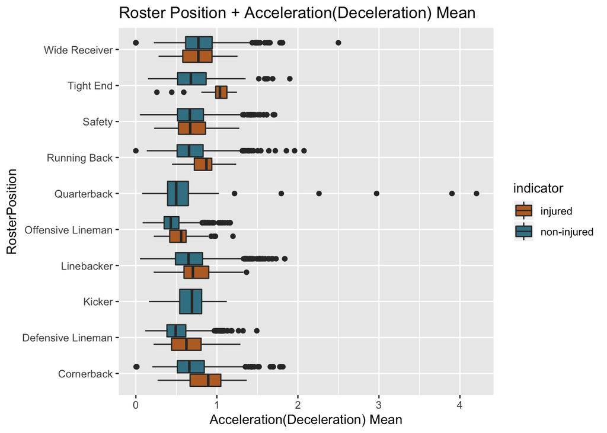

```r
ggplot(NFL_data_resample,aes(x=RosterPosition,y=mean_acc,fill=indicator)) +
  geom_boxplot() +
  scale_fill_manual(values = plot_cols[c(3,2)]) +
  scale_colour_manual(values = plot_cols[c(3,2)]) +
  labs(x="RosterPosition",y="Acceleration(Deceleration) Mean")+
  ggtitle("Roster Position + Acceleration(Deceleration) Mean") +
  coord_flip()
```

Telling from the roaster position + |acceleration/deceleration| plot, we noticed that players in their injured tracks are more likely to accelerate and decelerate suddenly

### d. Roaster Position + Distance

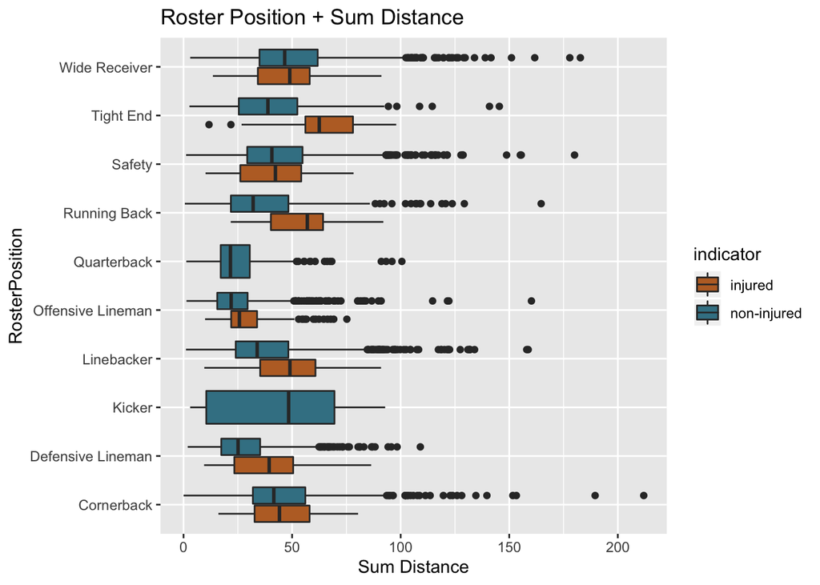

```r
ggplot(NFL_data_resample,aes(x=RosterPosition,y=sum_dis,fill=indicator)) +
  geom_boxplot() +
  scale_fill_manual(values = plot_cols[c(3,2)]) +
  scale_colour_manual(values = plot_cols[c(3,2)]) +
  labs(x="RosterPosition",y="Sum Distance")+
  ggtitle("Roster Position + Sum Distance") +
  coord_flip()
```

For the total distance of each track, majority positions’ players tend to run a longer distance during their injured tracks.

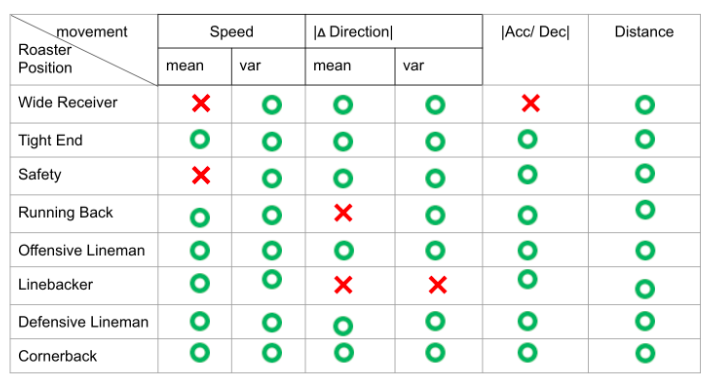

From our previous discussions, this player movement matrix can capture significant differences between injury tracks and noninjury tracks across majority of roaster positions

## Field Surface

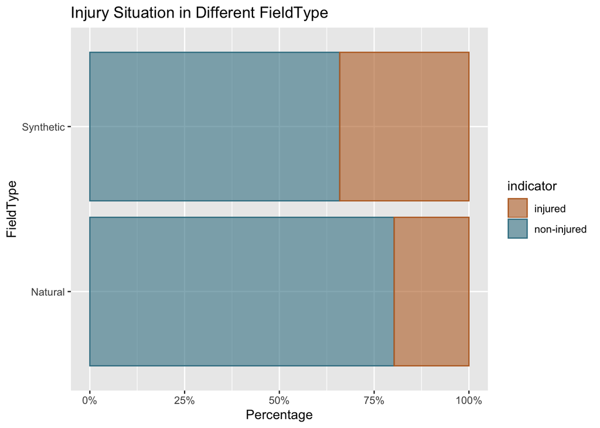

```r
NFL_data_resample%>%
  ggplot(aes(x=FieldType, fill = indicator, colour = indicator)) +
  geom_bar(stat = "count", position = "fill", alpha = 0.6) +
  scale_fill_manual(values = plot_cols[c(3,2)]) +
  scale_colour_manual(values = plot_cols[c(3,2)]) +
  scale_y_continuous(labels = percent) + labs(x = "FieldType", y="Percentage")+
  ggtitle("Injury Situation in Different FieldType") + coord_flip()
```

```r
table(NFL_data_resample$indicator, NFL_data_resample$FieldType)
```

```
##
##               Natural Synthetic
##   injured        1508      1692
##   non-injured    6136      3272
```

```r
chisq.test(table(NFL_data_resample$indicator, NFL_data_resample$FieldType))
```

```
##
##  Pearson's Chi-squared test with Yates' continuity correction
##
## data:  table(NFL_data_resample$indicator, NFL_data_resample$FieldType)
## X-squared = 326.82, df = 1, p-value < 2.2e-16
```

Another important feature that might relates to football injury is field surface (synthetic turf or natural turf) We apply chi-square test and conclude that there is a significant correlation between field surface injury cases.

Recent investigations of lower limb injuries among football athletes have indicated significantly higher injury rates on synthetic turf compared with natural turf because that synthetic turf surfaces do not release cleats as readily as natural turf and may contribute to the incidence of non-contact lower limb injuries (Kent et al., 2015).

## Logistic Regression

```r
NFL_data_resample_subset <- NFL_data_resample[NFL_data_resample$Weather!="indoors" | NFL_data_resample$StadiumType %in% c("dome_closed","indoor_closed"),]
NFL_data_resample_subset <- NFL_data_resample_subset[NFL_data_resample_subset$Weather!="unknown",]
NFL_data_resample_subset$indicator <- ifelse(NFL_data_resample_subset$indicator=="non-injured",0,1)
## Consider environment
NFL_data_resample_subset$Indoor <- ifelse(NFL_data_resample_subset$StadiumType %in% c("dome_closed","indoor_closed") | NFL_data_resample_subset$Weather=="indoors",1,0)
NFL_data_resample_subset$Outdoor_rain  <- ifelse(NFL_data_resample_subset$StadiumType == "Outdoor" & NFL_data_resample_subset$Weather=="rain",1,0)
NFL_data_resample_subset$Outdoor_overcast  <- ifelse(NFL_data_resample_subset$StadiumType == "Outdoor" & NFL_data_resample_subset$Weather=="overcast",1,0)
NFL_data_resample_subset$Outdoor_clear  <- ifelse(NFL_data_resample_subset$StadiumType == "Outdoor" & NFL_data_resample_subset$Weather=="clear",1,0)
NFL_data_resample_subset$Outdoor_snow  <- ifelse(NFL_data_resample_subset$StadiumType == "Outdoor" & NFL_data_resample_subset$Weather=="snow",1,0)
NFL_data_resample_subset$Indoor_rain  <- ifelse(NFL_data_resample_subset$StadiumType %in% c("dome_open","indoor_open") & NFL_data_resample_subset$Weather=="rain",1,0)
NFL_data_resample_subset$Indoor_overcast  <- ifelse(NFL_data_resample_subset$StadiumType %in% c("dome_open","indoor_open") & NFL_data_resample_subset$Weather=="overcast",1,0)
NFL_data_resample_subset$Indoor_clear  <- ifelse(NFL_data_resample_subset$StadiumType %in% c("dome_open","indoor_open") & NFL_data_resample_subset$Weather=="clear",1,0)
NFL_data_resample_subset$Indoor_snow  <- ifelse(NFL_data_resample_subset$StadiumType %in% c("dome_open","indoor_open") & NFL_data_resample_subset$Weather=="snow",1,0)

fit <- glm(indicator ~ sum_dis + mean_speed + var_speed + mean_dir + var_dir + mean_acc + FieldType + Temperature + Indoor + Outdoor_rain + Outdoor_overcast + Outdoor_clear + Outdoor_snow,
             data = NFL_data_resample_subset, family = "binomial")
summary(fit)
```

```
##
## Call:
## glm(formula = indicator ~ sum_dis + mean_speed + var_speed +
##     mean_dir + var_dir + mean_acc + FieldType + Temperature +
##     Indoor + Outdoor_rain + Outdoor_overcast + Outdoor_clear +
##     Outdoor_snow, family = "binomial", data = NFL_data_resample_subset)
##
## Deviance Residuals:
##     Min       1Q   Median       3Q      Max
## -3.3104  -0.6556  -0.4653  -0.0005   2.4938
##
## Coefficients:
##                      Estimate Std. Error z value Pr(>|z|)
## (Intercept)        -1.407e+00  2.006e-01  -7.011 2.36e-12 ***
## sum_dis            -1.103e-03  1.758e-03  -0.627  0.53040
## mean_speed         -1.942e+00  1.067e-01 -18.199  < 2e-16 ***
## var_speed           6.550e-01  2.129e-02  30.757  < 2e-16 ***
## mean_dir           -1.131e-01  1.709e-02  -6.619 3.61e-11 ***
## var_dir             5.038e-04  6.700e-05   7.519 5.51e-14 ***
## mean_acc            1.272e+00  1.559e-01   8.159 3.38e-16 ***
## FieldTypeSynthetic  5.059e-01  5.227e-02   9.678  < 2e-16 ***
## Temperature         1.755e-02  1.639e-03  10.707  < 2e-16 ***
## Indoor             -3.603e-01  1.162e-01  -3.100  0.00193 **
## Outdoor_rain       -2.883e-01  1.379e-01  -2.091  0.03652 *
## Outdoor_overcast   -1.079e+00  1.162e-01  -9.283  < 2e-16 ***
## Outdoor_clear      -1.050e+00  1.161e-01  -9.044  < 2e-16 ***
## Outdoor_snow       -1.411e+01  1.430e+02  -0.099  0.92143
## ---
## Signif. codes:  0 '***' 0.001 '**' 0.01 '*' 0.05 '.' 0.1 ' ' 1
##
## (Dispersion parameter for binomial family taken to be 1)
##
##     Null deviance: 13801  on 12363  degrees of freedom
## Residual deviance: 10978  on 12350  degrees of freedom
## AIC: 11006
##
## Number of Fisher Scoring iterations: 14
```